# SURVIVAL DATA AND ANALYSIS

## **INTRODUCTION**

*What is Survival Data?*

**Survival data** also called “time-to-event data”, is data collected on tracking the time until a specific event happens or occurs.  
**NOTE:** Typically, survival data are not fully observed, but rather are censored.

censoring occurs when we have some information about individual survival time, but we don’t know the survival time exactly. This is caused by  
1. study ends and no event  
2. lost to follow-up during the study period  
3. withdraw from the studies.

This is called right censoring, which is the common assumption and data used in survival analysis. We have other forms of censoring like *left censoring*, *interval censoring*, *informative* and *non-informative censoring*

**Illustration of survival data**

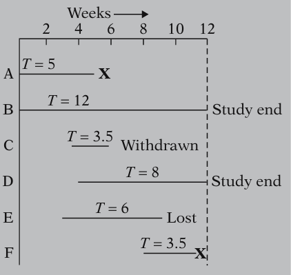

**X** = event

From the diagram,

- Individuals do not all enter the study at the same time
- When the study ends, some individuals still haven’t had the event yet
- Other individuals drop out or get lost in the middle of the study, and all we know about them is the last time they were still “free” of the event

**Survival Analysis** is a collection of statistical procedures for analyzing survival data for which the outcome variable of interest is **time until an event occurs**.

This *time* can be years, months, weeks, or days from the beginning of follow-up of an individual until an event occurs.

The *Event* can be death, disease, or recovery

*Example*

- time to death
- time to onset (or relapse) of a disease
- length of stay in a hospital
- duration of a strike
- money paid by health insurance
- viral load measurements
- time to finishing a doctoral dissertation

*Kinds of survival studies include:*

- clinical trials
- prospective cohort studies
- retrospective cohort studies
- retrospective correlative studies

*Why Survival Analysis?*

Survival analysis is very powerful statistical technique that take into account censoring data, comparing groups, estimating survival probabilities and analyzing the effects of covariates.

## **METHODOLOGY**

The non-negative random variable $T$ denotes the **Survival Time**. Thus the time an individual survives until the event. The event is term as **Failure** because we have failed when we stop surviving. This can be negative or positive event.

$T \geq 0$. (**discrete** or **continuous**)

$t$ denotes any specific value of interest for the random variable $T$.

$\delta_i$ is called **Failure Indicator**

$$\delta(t) =
\begin{cases}
1, & \text{if failure} \\
0, & \text{if censored}
\end{cases}$$

$S(t)$ is called **survivor function** and this gives the probability that a person survives longer than some specified time $t$

$S(t)$ = $P(T>t)$ = $1-F(t)$, where $F(t)$= $P(T \le t)$ $f(t)$ is the **density function**

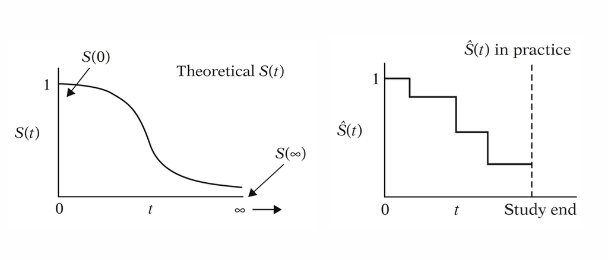

$h(t)$ or $\lambda(t)$ is called **hazard function** and gives the instantaneous potential per unit time for the event to occur, given that the individual has survived up to time $t$

$h(t) = \lim \limits_{\Delta t \to 0} \frac {P(t \le T < t + \Delta t | T \ge T)}{\Delta t} = \frac{f(t)}{S(t)}$

$\Lambda(t)$ or $H(t)$ is the **cumulative hazard function**

**The relationship between the hazard function and the survivor function**  
$h(t) = - \ \frac{d}{dt} [\log S(t)]$

$S(t) = e^{ - H(t)}$

# Estimating the survivor or hazard function

We can estimate the survival ( or hazard) function in two ways:

1. By developing an empirical estimate of the survival function( i.e., non-parametric estimation)
2. By specifying a parametric model for $h(t)$ based on a particular density function $f(t)$.

**• If no censoring:**  
The empirical estimate of the survivor function, $\tilde{S}(t)$ , is the proportion of individuals with event times greater than $t$.

$\tilde{S}(t) = \frac{\text{number of individual with} \quad T \geq t} {\text{total sample size}}$

**• With censoring:**  
If there are censored observations, then $\tilde{S}(t)$ is not a good estimate of the true $S(t)$.  
Non-parametric methods such as **Cumulative hazard estimator (Nelson-Aalen estimator)** , **life-table (Actuarial method)** and **Kaplan-Meier** estimator can be used to account for censoring

**Kaplan-Meier estimator** is the famous non-parametric approach for estimating the survival distribution

**Kaplan–Meier** estimation of survivor function is given by:  
$\hat{S}_{KM}(t) = \prod \limits_{t_i \leq t} \left( 1 - \frac{d_i}{r_i}\right) \quad$ *where*

$t_i$ are the observed event times (failure times).  
$d_i$ is the number of events (failures) at time $t_i$.  
$r_i$ is the number of individuals at risk just before $t_i$.

**Log-Rank Test** is used to compares survival curves of different groups in a Kaplan-Meier survival analysis and is given by:

Log-Rank Statistic $= \sum \limits_{i} \frac{\left( o_i - e_i \right)^2}{v_i} \sim \chi_{k-1} ^2$ where $k$ is the number of groups

$o_i$ is the observed number of events in group $i$  
$v_i$ is the variance of the expected number of events in group $i$  
$v_i = \sum \frac{di}{\hat{H}(t)}\left( \frac{1}{r_i}-\frac{1}{r_{i-1}}\right)$

$e_i$ is the expected number of events in group $i$ $e_i = \frac{r_i}{r} d$  
$r_i$ is number individuals at risk in group $i$  
$d$ is total number of events  
$r$ is total number of individuals at risk

**Confidence Interval** is given by: $\log (\hat{S}_{KM}(t)) \pm Z_{1-\frac{\alpha}{2}} \times SE[\log (\hat{S}_{KM}(t))]$

Where $SE$ is the standard error of the estimator and is given by  
$SE= \hat{S}_{KM}(t) \times \sqrt{ \sum \limits_{t_i \leq t} \frac{d_i}{n_i(n_i-d_i)}}$ This is also called **Greenwood formula**

$n_i$ denotes the number of individuals at risk just prior to time $t_i$

**Nelson-Aalen estimator** estimation of the cumulative hazard function is given by:

$\hat{H}(t) = \sum \limits_{t_i \leq t} \frac{d_i}{r_i}$

# Cox Proportional Hazard Regression Model (Cox-PH Model)

This is a semi-parametric and regression model used to examine the effect of different variables (covariates) on survival time.

$h(t,X) = h_{0}(t) \exp^{\beta_{1}X_{1}+\beta_{2}X_{2}+...+\beta_{p}X_{p}}$

$h_{0}(t)$ is the baseline function

$X_{1}, X_{2},... ,X_{p}$ are the explanatory variables(e.g age, treatment).

$\beta$ values show the effect of covariates on the survival

**Assumptions of the model**

1. non-informative censoring (censoring is not related to the individual’s risk of experiencing the event)
2. proportional hazards (the effect of a covariate on the hazard (the risk of the event occurring) is assumed to remain the same across the entire study period

**Likelihood Ratio**  
The likelihood ratio test is a robust method for comparing nested models like Cox proportional hazards model.

[Partial Likelihood] $L_p(\beta) = \prod \limits_{i =1}^{n}\left[ \frac{\exp ^ {(\beta X_i)}} {\sum \limits_{j \in R(T_i)} \exp ^ {(\beta X_j) }}\right]^{\delta_i}$

$T_i$ denotes the observed time (either event or censoring) for individual $i$

$R(T_i)$ represents the risk set at time $T_i$, comprising individuals still at risk just before time $T_i$

**Likelihood Ratio ($\Lambda$)** $= -2( \log L_0(simplest) - \log L_1(complex)$

$\quad \quad \Lambda \sim \chi_1 ^2$

## **EXAMPLES**

**Example 1**  
Let use the lung data set from “Survival” package.

**Data Description**  
Survival in patients with advanced lung cancer from the North Central Cancer Treatment Group. Performance scores rate how well the patient can perform usual daily activities.

**Example 2**

The following data represents remission times(weeks) of leukemia patients in two groups. The first group is the treatment group and the second is Placebo group. **How can we compare their survival times statistically??**

## **R IMPLEMENTATION**

Packages

```r
#install.packages("survival")
#install.packages("survminer")
#install.packages("ggpubr")
#install.packages("dplyr")
#install.packages("simsurv") for parametric simulations
#install.packages("coxed") for simulation from Cox-PH
```

Libraries

```r
library(survival)
library(survminer)
library(simsurv)
library(knitr)
library(ggpubr)
library(ggplot2)
library(dplyr)
library(coxed)
```

**Example 1**

```r
# Create a survival dataset

data=lung
head(data)
```

```
##   inst time status age sex ph.ecog ph.karno pat.karno meal.cal wt.loss
## 1    3  306      2  74   1       1       90       100     1175      NA
## 2    3  455      2  68   1       0       90        90     1225      15
## 3    3 1010      1  56   1       0       90        90       NA      15
## 4    5  210      2  57   1       1       90        60     1150      11
## 5    1  883      2  60   1       0      100        90       NA       0
## 6   12 1022      1  74   1       1       50        80      513       0
```

```r
# Recoding the status

data$status = ifelse(lung$status == 1, 0, 1)
head(data)
```

```
##   inst time status age sex ph.ecog ph.karno pat.karno meal.cal wt.loss
## 1    3  306      1  74   1       1       90       100     1175      NA
## 2    3  455      1  68   1       0       90        90     1225      15
## 3    3 1010      0  56   1       0       90        90       NA      15
## 4    5  210      1  57   1       1       90        60     1150      11
## 5    1  883      1  60   1       0      100        90       NA       0
## 6   12 1022      0  74   1       1       50        80      513       0
```

```r
# Create survival object
```

Kaplan-Meier estimator

```r
KM_fit = survfit(Surv(time, status) ~ 1, data = data)
KM_fit
```

```
## Call: survfit(formula = Surv(time, status) ~ 1, data = data)
##
##        n events median 0.95LCL 0.95UCL
## [1,] 228    165    310     285     363
```

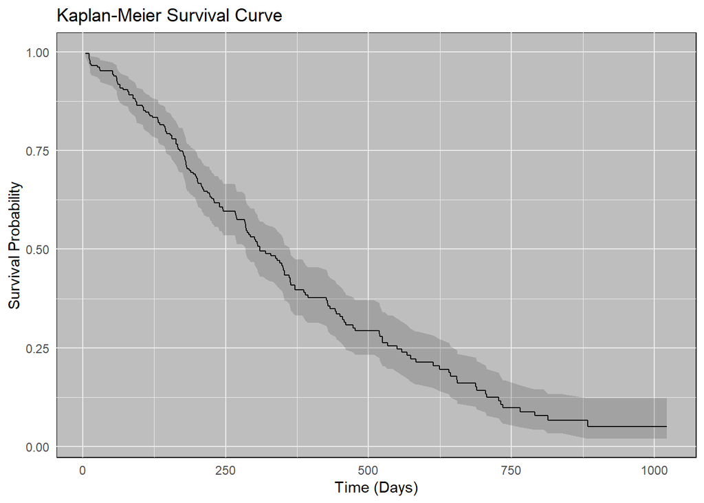

```r
# Print survival probabilities


# Plot the survival curve
KM_data = data.frame(
  time = KM_fit$time,   # Time points
  surv = KM_fit$surv,   # Survival probabilities
  lower = KM_fit$lower, # Lower bound of confidence interval
  upper = KM_fit$upper  # Upper bound of confidence interval
)

ggplot(KM_data, aes(x = time, y = surv)) +
  geom_step() +
  geom_ribbon(aes(ymin = lower, ymax = upper), alpha = 0.2) +
  labs(title = "Kaplan-Meier Survival Curve",
       x = "Time (Days)",
       y = "Survival Probability") +
  theme_minimal() + theme(panel.background = element_rect(fill = "gray"),)
```

The hazard function

```r
# Compute the Nelson-Aalen estimator
NA_fit = survfit(Surv(time, status) ~ 1, data = data, type = "fh")
#summary(NA_fit)
```

Cox proportional hazards model

```r
cox_fit = coxph(Surv(time, status) ~ age + sex, data = data)
survfit(cox_fit)
```

```
## Call: survfit(formula = cox_fit)
##
##        n events median 0.95LCL 0.95UCL
## [1,] 228    165    320     285     363
```

```r
summary(cox_fit)
```

```
## Call:
## coxph(formula = Surv(time, status) ~ age + sex, data = data)
##
##   n= 228, number of events= 165
##
##          coef exp(coef)  se(coef)      z Pr(>|z|)
## age  0.017045  1.017191  0.009223  1.848  0.06459 .
## sex -0.513219  0.598566  0.167458 -3.065  0.00218 **
## ---
## Signif. codes:  0 '***' 0.001 '**' 0.01 '*' 0.05 '.' 0.1 ' ' 1
##
##     exp(coef) exp(-coef) lower .95 upper .95
## age    1.0172     0.9831    0.9990    1.0357
## sex    0.5986     1.6707    0.4311    0.8311
##
## Concordance= 0.603  (se = 0.025 )
## Likelihood ratio test= 14.12  on 2 df,   p=9e-04
## Wald test            = 13.47  on 2 df,   p=0.001
## Score (logrank) test = 13.72  on 2 df,   p=0.001
```

```r
# The 'step' function can also be used here
```

Example 2

```r
# first data set
Time1=c(6,6,6,7,10,13,16,22,23,6,9,10,11,17,19,20,25,32,32,34,35)
Status1=c(1,1,1,1,1,1,1,1,1,0,0,0,0,0,0,0,0,0,0,0,0)
Group1=rep("Group 1", length(Time1))

# second data set
 Time2 = c(1,1,2,2,3,4,4,5,5,8,8,8,8,11,11,12,12,15,17,22,23)
 Status2 = c(0,1,1,1,1,1,1,1,1,0,0,1,1,1,1,1,1,1,1,0,0)
 Group2 = rep("Group 2", length(Time2))

 # combined data set
 Time =c(Time1, Time2)
 Status =c(Status1, Status2)
 Group=factor(c(Group1, Group2)) #convert to factor variable.

 # Create a survival object
surv_obj = Surv(Time, Status)

# Fit Kaplan-Meier survival curves
km_fit = survfit(surv_obj ~ Group)

# Perform Log-Rank Test to compare the groups
logrank_test = survdiff(surv_obj ~ Group)
logrank_test
```

```
## Call:
## survdiff(formula = surv_obj ~ Group)
##
##                N Observed Expected (O-E)^2/E (O-E)^2/V
## Group=Group 1 21        9    15.97      3.04      8.99
## Group=Group 2 21       16     9.03      5.39      8.99
##
##  Chisq= 9  on 1 degrees of freedom, p= 0.003
```

Plot of Kaplan Meier Curves

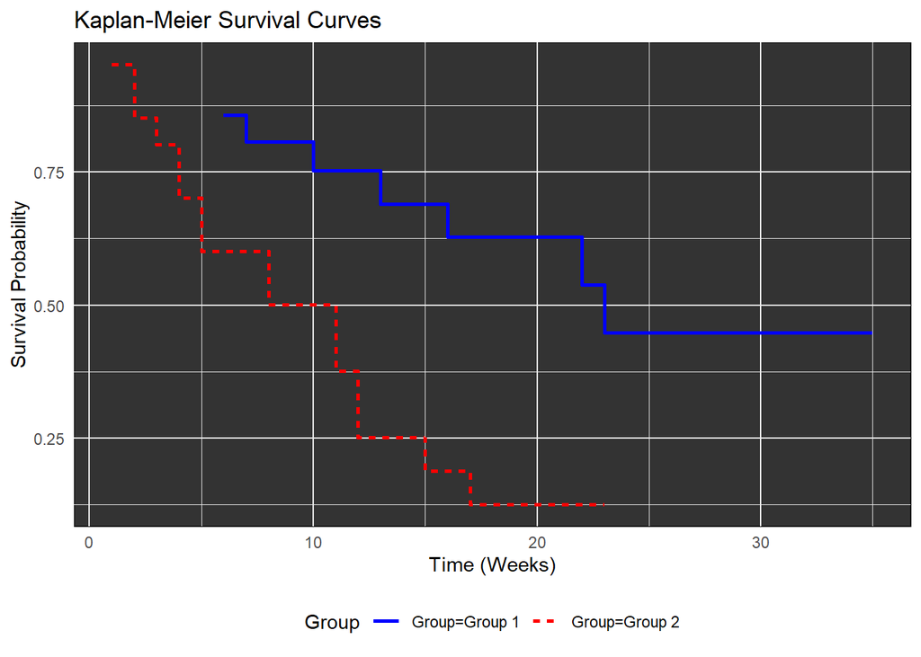

```r
# Convert Kaplan-Meier object to a tidy data frame for ggplot
km_data =data.frame(
  time = km_fit$time,
  surv = km_fit$surv,
  strata = factor(rep(names(km_fit$strata), km_fit$strata))
)

ggplot(km_data, aes(x = time, y = surv, color = strata, linetype = strata)) +
  geom_step(size = 1) +  # Step plot for survival curves
  labs(title = "Kaplan-Meier Survival Curves",
       x = "Time (Weeks)",
       y = "Survival Probability",
       color = "Group",
       linetype = "Group") +
  theme_minimal() +
  scale_color_manual(values = c("blue", "red")) +
  theme(legend.position = "bottom" ,
        panel.background = element_rect(fill = "gray20"))
```

# Simulations Techniques

Weibull

```r
set.seed(123)

lambda = 0.1  # Scale parameter
gamma = 1.5   # Shape parameter

# Simulate survival times for 200 individuals
sim_data2 = simsurv(dist = "weibull",lambdas = lambda,gammas = gamma, x = data.frame(id = 1:200),maxt = 100)
```

Simulating using Cox proportional hazards models

```r
set.seed(123)
#Simulate a survival dataset with 1000 observations and maximum time of 100

sim_data3 = sim.survdata(N = 1000, T = 100) #coefficients, covariates and function will be set by default

 ### Customization
beta_values = c(0.5, -0.3, 0.2, -0.1, 0.4)
customize_function=function(t) { 0.1 * exp(-0.02 * t) }

sim_data4 = sim.survdata(N = 1000, T = 100, xvars = 5, beta = beta_values, hazard.fun = customize_function)
#sim_data4
```

# Reference

Kleinbaum, D. G., & Klein, M. (2012). Introduction to survival analysis. In Survival analysis: A self-learning text (3rd ed., pp. 1–33). Springer.